Meetup R Nantes

Le Bilan 2016/2017

# Meetup R Nantes - Bilan 2016/2017

12 juin 2017

### Meetup R Nantes Bilan 2016/2017

[figure not shown]

Meetup R Nantes : 2016/2017

# Pourquoi le “Meetup R Nantes” ?

- Envie de rencontrer et d’échanger avec d’autres utilisateurs de R
- Envie de partager des connaissances R
- Envie d’en apprendre plus sur R et ses possibles utilisations
- Envie de démocratiser R comme outil indispensable pour tout ce qui touche à la donnée

# Rétrospective

- Timeline :

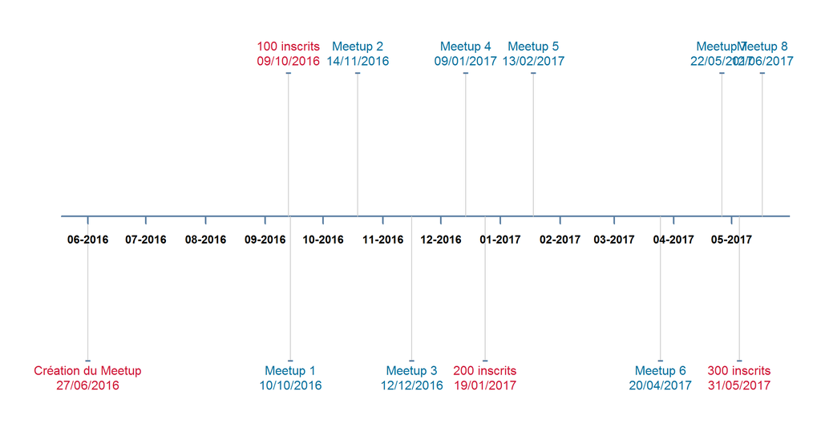

# Quelques chiffres

Nombre total d’inscrits sur la page : 308

[interactive chart not shown]

# Evolution au cours du temps

[interactive chart not shown]

# Qui sont les inscrits ?

- Wordcloud des biographies des inscrits :

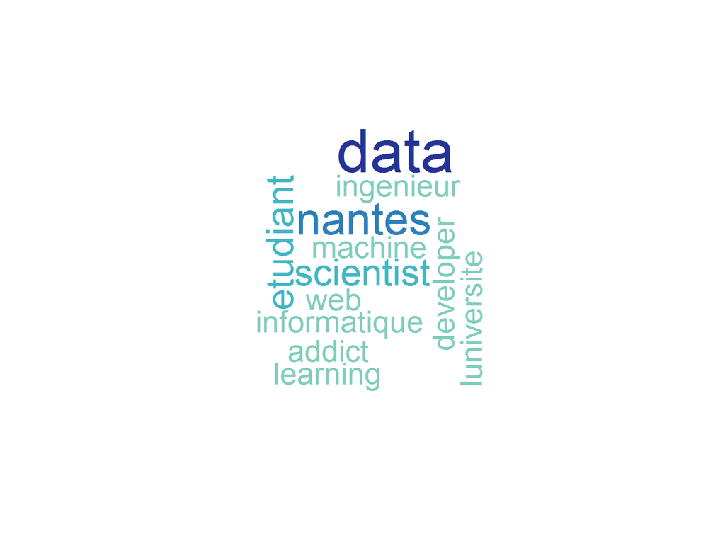

# D’où viennent-ils ?

[interactive chart not shown]

# De quoi parle-t-on ?

- Wordcloud des descriptions des meetups :

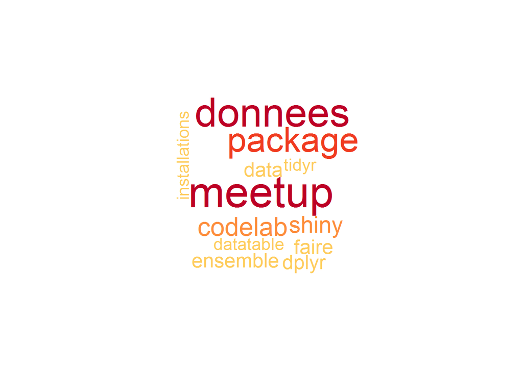

# Merci aux sponsors

[figure not shown]

Meetup R Nantes : 2017/2018

# Idées de thématiques pour l’an prochain

- Industrialisation de projets data science R : retour d’expériences
- Les fonctions en R
- Optimisation de code R : basé sur la lecture d’un ouvrage
- Présentation d’un cas d’exemple d’utilisation de R pour des données de mobilité
- Codelab R et mongoDB
- Codelab R et dataviz avec Christophe Cariou
- Manipulation de données avec “dplyr” : 2ème édition, avec Wilfrid Cariou
- Codelab R Shiny #3

# Proposez vos idées :)

[figure not shown]

- Quels thèmes / sujets souhaiteriez-vous voir abordés lors des prochaines rencontres ?
- Quels thèmes / sujets souhaiteriez-vous venir présenter lors des prochaines rencontres ?

=> Questionnaire en ligne pour faire vos propositions pendant tout l’été : https://goo.gl/forms/DALxhyzVMpzNmOP02

# Prochaine rencontre

Prochaine rencontre : octobre 2017 !

Gardez un oeil sur :

- La page du groupe : [Meetup R Nantes](https://www.meetup.com/fr-FR/Meetup-R-Nantes/)
- Le compte Twitter : [Twitter @meetup_r_nantes](https://twitter.com/meetup_r_nantes)
- Vos mails si vous êtes inscrits sur la page meetup ;)

[figure not shown]

# Merci à tous !

[figure not shown]